# Bayesian Sample Size Determination for Residential PM₂.₅ Exposure and Brain Structure

Required $n$ under the laboratory’s Bayesian-Lasso pipeline: at least one brain principal component significant on the residential PM$_{2.5}$ exposure index

Author

Amaru Agüero

Published

August 24, 2026

Abstract

How many participants are needed to link fine particulate air pollution to brain structure in our cohort? We simulated thousands of complete virtual studies and analysed each one exactly as the laboratory will analyse the real data: a Bayesian Lasso regression that searches, across twenty brain components plus age, for at least one component related to the residential PM$_{2.5}$ exposure index, in either direction. The virtual data are realistic on both sides: exposure values are drawn from the actual long-term PM$_{2.5}$ concentrations of the participants’ residential comunas (the laboratory’s monitor-calibrated PM$_{2.5}$ model surface, 2013–2022; $600$ participants across $52$ comunas, mean $24.6$, SD $3.2$ $\mu$g/m$^{3}$), and brain measures reproduce the variability of our own DKT cortical-thickness data. The required sample size is the smallest $n$ at which at least $80\%$ of the virtual studies succeed. The answer: $n=42$ suffices when the exposure–brain link is strong ($\rho=0.5$), $n=75$ when it is moderately strong ($\rho=0.4$), and $n=142$ when it is moderate ($\rho=0.3$); if the signal is spread over two brain components, $n=78$. We also report the posterior standardized $\beta$ that a reader interprets: the Lasso shrinks it to roughly $64$–$77\%$ of its true value, so published effect sizes from this pipeline are conservative. Applying the same logic to Cohort 2 (MCI vs. controls, with the PM$_{2.5}$ exposure included in the model), $42$ per group detect large group differences ($d=0.8$) and $26$ per group suffice for $d=1.0$. Given the modest exposure–brain effects reported in the air-pollution literature and the limited exposure contrast within one metropolitan area, the moderate-effect scenarios should be treated as the realistic planning range.

# 1 Introduction

Fine particulate matter (PM$_{2.5}$) is an established neurotoxic exposure: chronic inhalation is linked to accelerated cognitive decline, structural brain differences and dementia risk, plausibly through neuroinflammatory and cerebrovascular pathways. Santiago’s metropolitan region combines high average concentrations with a strong west–east gradient, so a cohort recruited across its comunas carries a real, measurable exposure contrast. This report asks the design question for the exposure arm of the study: *what sample size $n$ yields, with probability $\ge0.80$, that at least one brain principal component is significant on the residential PM$_{2.5}$ exposure index, in a two-sided sense (its $95\%$ credible interval excludes zero), under the laboratory’s Bayesian-Lasso pipeline?*

The analysis mirrors the laboratory’s practice: the exposure index is regressed on the full set of brain principal components plus age with the hierarchical Bayesian Lasso used by the group (the JAGS `model_string_Lasso`), and a study succeeds when any brain component is credibly associated with the exposure. Section 2 describes the exposure calibration, the choice of a scalar exposure index, the generative model, the analysis model and detection criterion; Section 3 reports the required $n$, the recovery of the posterior standardized $\beta$, the sensitivity analyses, and Cohort 2; Section 4 states the conclusions.

# 2 Methods

## 2.1 Exposure calibration and the scalar-vs-component decision

**Exposure assignment.** Each participant’s long-term exposure is the 2013–2022 mean PM$_{2.5}$ concentration of their residential comuna from the laboratory’s own PM$_{2.5}$ model surface: a LightGBM ensemble trained on SINCA monitor data with satellite aerosol optical depth (MAIAC), MERRA-2 and ERA5 meteorology and land-use predictors, validated against monitors at daily $r=0.70$, FAC2 $=0.87$ and mean bias $-5\%$ ($95{,}446$ station-days). After normalising comuna names in the recruitment database, $600$ of $601$ valid records were assigned an exposure, spanning $52$ comunas. The participant-level distribution has mean $24.6$ $\mu$g/m$^{3}$, SD $3.2$, range $4.6$–$32.9$ and skewness $-1.03$: the highest exposures are in western Santiago comunas (Cerro Navia, Pudahuel, Estación Central $\approx28$–$30$), with a lower tail from residents of Las Condes, Lo Barnechea and a few participants outside the metropolitan region (Figure 1A–B). At the comuna level the model surface agrees with the ACAG satellite product (Donkelaar et al. 2021) ($r=0.71$, identical cohort mean) while resolving stronger within-city contrasts.

**Scalar rather than a principal component.** The exposure repository provides several candidate metrics per comuna, all derived from the same hourly model surface: long-term mean, average peak level, hours above $50$ $\mu$g/m$^{3}$, cumulative dose above $50$, and episode counts. At the comuna level these metrics correlate $0.82$–$1.00$ (Figure 1C): they form essentially one dimension, so a first principal component of them would carry over $90\%$ of their variance while adding no information and losing the direct per-$\mu$g/m$^{3}$ reading. We therefore use the **scalar long-term mean** as the exposure index, standardized within the cohort; effect sizes $\rho$ below are per SD of exposure ($1$ SD $=3.2$ $\mu$g/m$^{3}$ in this cohort).

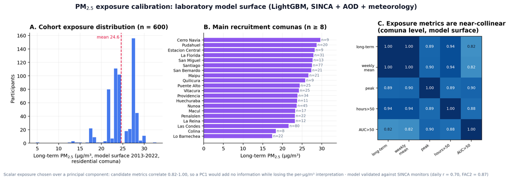

PM$_{2.5}$ exposure calibration. (A) Participant-level long-term exposure distribution. (B) Main recruitment comunas. (C) Candidate exposure metrics are near-collinear at the comuna level, justifying the scalar index.

**Brain components.** As in the hormonal analysis of this project, the brain side is calibrated from the laboratory’s DKT-atlas cortical-thickness data restricted to the 40–55-year window ($54$ participants $\times$ 62 ROIs): PC1 carries $60.4\%$ of the variance (global thickness) and correlates with age at $r=-0.171$; components 1–10 explain $86.8\%$, 1–14 $90.8\%$ and 1–20 $94.7\%$. The primary simulation retains $K=20$ components (the laboratory’s ICA default), with $K=14$, $10$ and $5$ as sensitivity analyses.

## 2.2 Generative model (Cohort 1)

For each simulated participant $i=1,\dots,n$, with standardized age $a_i\sim\mathcal{N}(0,1)$:
$$\begin{aligned}
\mathrm{PCb}_{i1} &= c_b\, a_i + \sqrt{1-c_b^{2}}\;e_{i1}, \qquad c_b=-0.17,\nonumber\\
\mathrm{PCb}_{ij} &\sim \mathcal{N}(0,1) \quad j=2,\dots,K,\\[2pt]
y_i &= \textstyle\sum_{j\in\mathcal{T}} \rho\,\mathrm{PCb}_{ij}
\;+\; \sqrt{1-|\mathcal{T}|\rho^{2}}\;\varepsilon_i,
\qquad \varepsilon_i\sim\mathcal{N}(0,1),
\end{aligned}$$
where $y$ is the standardized PM$_{2.5}$ exposure index and $\mathcal{T}$ indexes the truly associated brain component(s) with standardized effect $\rho$ each. Unlike the hormonal index, the exposure has no age dependence in the cohort database, so its age coefficient is set to zero; age still enters the design matrix as a covariate because the first brain component is age-related. The true components are never the age-related first component. Scenarios: one true component with $\rho\in\{0.2,0.3,0.4,0.5\}$; two true components with $\rho=0.3$ each; and the global null.

## 2.3 Analysis model, detection criterion, and reported coefficient

Each simulated dataset is analysed with the laboratory’s hierarchical Bayesian Lasso, with $y$ = exposure index and design matrix $[\mathrm{PCb}_{1},\dots,\mathrm{PCb}_{K},\ a]$, all $p=K{+}1$ predictors penalized:
$$y_i \sim \mathcal{N}\!\bigl(\beta_0 + \mathbf{x}_i^{\top}\boldsymbol\beta,\ \sigma^2\bigr),\quad
\beta_0\sim\mathcal{N}(0,10^2),\quad \sigma^2\sim\text{Inv-Gamma}(0.01,0.01),$$
$$\beta_j\mid\sigma^2,\tau_j^2 \sim \mathcal{N}(0,\sigma^2\tau_j^2),\quad
\tau_j^2\sim\text{Exp}(\lambda^2/2),
\qquad
\lambda = p\,\sqrt{\widehat{\mathrm{Var}}(\text{OLS residuals})}\Big/\sum_j|\hat\beta_j^{\mathrm{OLS}}| .$$
A brain component is significant when its equal-tailed $95\%$ credible interval excludes zero, in either direction; a study is a *success* when at least one of the $K$ brain components is significant, and $n^{*}$ is the smallest $n$ with success probability $\ge0.80$. The family-wise false-detection rate under the global null is reported alongside. We additionally evaluate the quantity a reader interprets, the posterior standardized $\beta$ of the associated component (population value $=\rho$ by construction): posterior mean, $95\%$ credible interval, shrinkage factor, coverage, and the probability that the largest posterior $|\beta|$ belongs to the truly associated component. As a complementary evidence scale, the default JZS Bayes factor on each component’s partial correlation (controls: remaining components + age; $m=n-K$) defines success at thresholds $\mathrm{BF}_{H_1/H_0}\ge4$, $6$, $10$. The batched exact Gibbs sampler and its verification against a scalar reference implementation and analytic Bayes factors are as described previously for this project ($400$ datasets per grid cell; $1{,}200$ for the $\beta$-recovery scenarios; $3{,}000$ iterations, $800$ burn-in).

## 2.4 Cohort 2 (MCI vs. HC, with the exposure in the model)

Cohort 2 follows the same logic with the group indicator as response: $y$ = standardized balanced group label (age-matched groups), design $=[\mathrm{PCb}_{1},\dots,\mathrm{PCb}_{20},\ \mathrm{PM}_{2.5},\ a]$, all penalized. One truly discriminating brain component carries an MCI–HC separation of Cohen’s $d\in\{0.5,0.65,0.8,1.0\}$; the PM$_{2.5}$ exposure enters with an optional MCI–HC separation $d_h\in\{0,0.3\}$ (plausible if cases and controls differ in residential exposure histories). The success criterion is unchanged: at least one *brain* component with $95\%$ CrI excluding zero; the significance of the exposure coefficient is tracked separately.

# 3 Results

## 3.1 Cohort 1: required $n$

Required $n$ for $P(\ge1$ brain component significant$)\ge0.80$ ($K=20$; two-sided $95\%$ CrI). “n.a.” = not attainable with $n\le160$.

| Scenario | Required $n$ |
| --- | --- |
| One component, $\rho=0.2$ | n.a. |
| One component, $\rho=0.3$ | **142** |
| One component, $\rho=0.4$ | **75** |
| One component, $\rho=0.5$ | 42 |
| Two components, $\rho=0.3$ each | **78** |

Operating characteristics at $n=60$ and $n=72$ ($K=20$, one true component). “Any” = design criterion; “true” = the truly associated component is among the significant ones.

|  | $n=60$ |  | $n=72$ |  |
| --- | --- | --- | --- | --- |
| True effect $\rho$ | any | true | any | true |
| 0.2 | 0.295 | 0.133 | 0.290 | 0.150 |
| 0.3 | 0.485 | 0.355 | 0.517 | 0.435 |
| 0.4 | 0.728 | 0.685 | 0.785 | 0.743 |
| 0.5 | **0.917** | **0.915** | **0.935** | **0.935** |
| $0$ (global null) | family-wise: 0.185 |  | 0.168 |  |

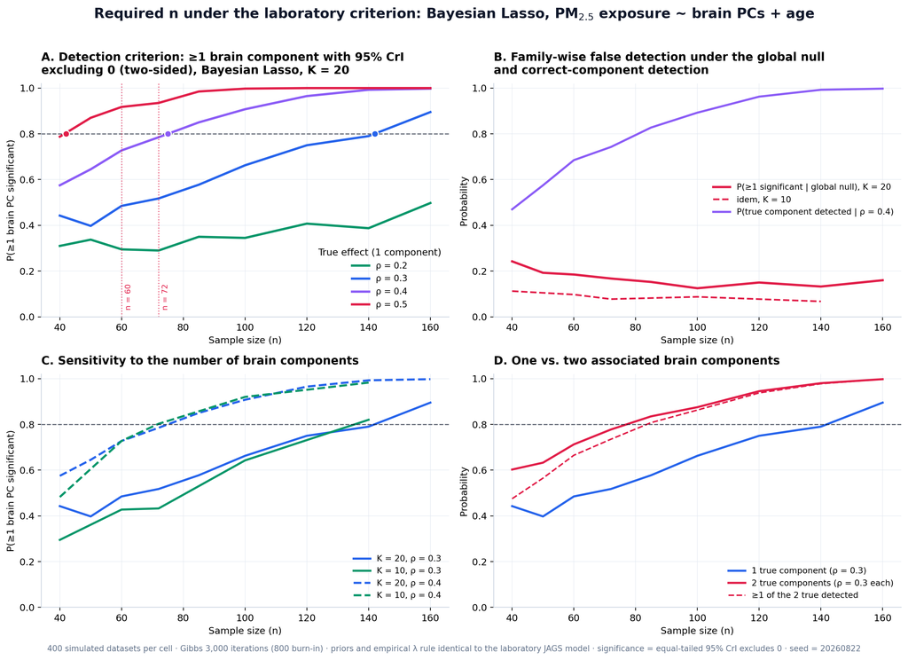

Required $n$ under the laboratory criterion for the PM$_{2.5}$ exposure index. (A) Probability that at least one brain component is significant, by true effect size. (B) Family-wise false detection under the global null and correct-component detection. (C) Sensitivity to $K$. (D) One vs. two associated components.

## 3.2 Posterior standardized $\beta$ of the associated component

Recovery of the posterior standardized $\beta$ ($K=20$ plus age; $1{,}200$ simulated studies per scenario). Effects are per SD of exposure ($3.2$ $\mu$g/m$^{3}$).

| $n$ | True $\beta$ | Posterior $\beta$ | Shrinkage | Median 95% CrI | Coverage | Selects true |
| --- | --- | --- | --- | --- | --- | --- |
| 60 | 0.30 | 0.192 | 0.64 | $[-0.02,\ 0.42]$ | 0.82 | 0.55 |
| 72 | 0.30 | 0.192 | 0.64 | $[-0.01,\ 0.40]$ | 0.79 | 0.62 |
| 100 | 0.30 | 0.205 | 0.68 | $[0.01,\ 0.39]$ | 0.79 | 0.76 |
| 134 | 0.30 | 0.214 | 0.71 | $[0.05,\ 0.37]$ | 0.78 | 0.88 |
| 60 | 0.40 | 0.280 | 0.70 | $[0.04,\ 0.51]$ | 0.79 | 0.79 |
| 72 | 0.40 | 0.294 | 0.74 | $[0.07,\ 0.51]$ | 0.81 | 0.87 |
| 60 | 0.50 | 0.385 | 0.77 | $[0.15,\ 0.61]$ | 0.80 | 0.95 |

Three properties of the reported coefficient follow (Figure 3). First, the Lasso prior shrinks the posterior $\beta$ towards zero: at $n=60$ the posterior mean recovers $64\%$ of a true $\beta=0.3$, $70\%$ of $0.4$ and $77\%$ of $0.5$, and for $\beta=0.3$ the factor climbs to $0.71$ at $n=134$. Published effect sizes from this pipeline are therefore conservative by construction: an estimated $\beta$ of $0.2$ per SD of exposure ($3.2$ $\mu$g/m$^{3}$) is compatible with a true effect near $0.3$. Second, as a direct consequence, the nominal $95\%$ credible interval covers the true value about $79\%$ of the time; the interval is calibrated for the shrunk posterior, not for the unshrunk parameter, which argues for reporting the interval together with the shrinkage factor. Third, precision and attribution improve steadily with $n$: the median interval width falls from $0.43$ at $n=60$ to $0.32$ at $n=134$ for $\beta=0.3$, and the probability that the largest posterior coefficient belongs to the truly associated component rises from $0.55$ to $0.88$ over the same range, already reaching $0.79$ at $n=60$ when $\beta=0.4$.

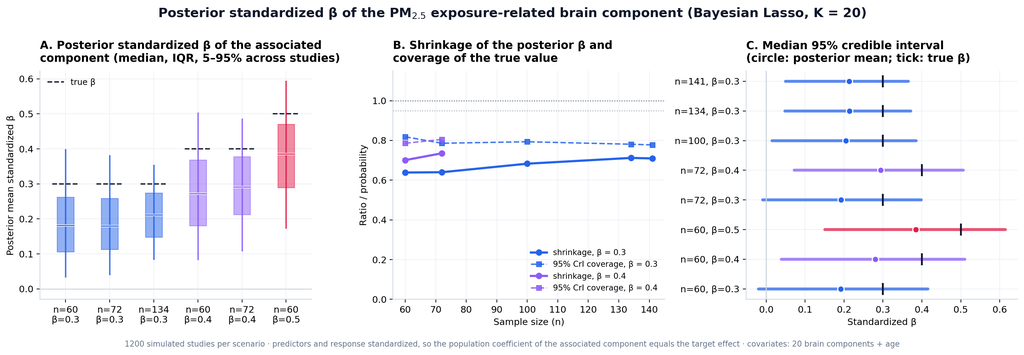

Posterior standardized $\beta$ of the PM$_{2.5}$-related brain component. (A) Distribution of the posterior mean across studies. (B) Shrinkage and coverage. (C) Median $95\%$ credible intervals (circle: posterior mean; tick: true $\beta$).

## 3.3 Sensitivity: number of components and Bayes-factor thresholds

Left: sensitivity of the required $n$ to the number of retained components (Lasso-CrI criterion; family-wise rate under the null at $n=72$). Right: required $n$ when success demands $\ge1$ component with $\mathrm{BF}_{H_1/H_0}$ above a threshold ($K=20$).

| Components | $n^{*}$, $\rho=0.3$ | $n^{*}$, $\rho=0.4$ | FW rate |
| --- | --- | --- | --- |
| $K=5$ | 128 | 71 | 0.043 |
| $K=10$ | 136 | 72 | 0.077 |
| $K=14$ (90% var.) | 137 | 74 | 0.113 |
| $K=20$ (lab ICA) | 142 | 75 | 0.168 |

Left: sensitivity of the required $n$ to the number of retained components (Lasso-CrI criterion; family-wise rate under the null at $n=72$). Right: required $n$ when success demands $\ge1$ component with $\mathrm{BF}_{H_1/H_0}$ above a threshold ($K=20$).

| $\rho$ | $\mathrm{BF}\ge4$ | $\mathrm{BF}\ge6$ | $\mathrm{BF}\ge10$ |
| --- | --- | --- | --- |
| 0.3 | n.a. | n.a. | n.a. |
| 0.4 | 92 | 99 | 109 |
| 0.5 | 63 | 68 | 73 |

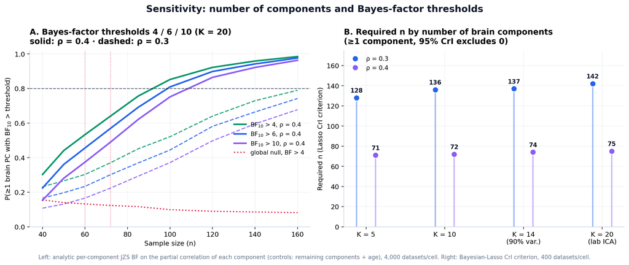

Sensitivity analyses for the PM$_{2.5}$ exposure. (A) Bayes-factor thresholds $4/6/10$ ($K=20$). (B) Required $n$ by number of retained components.

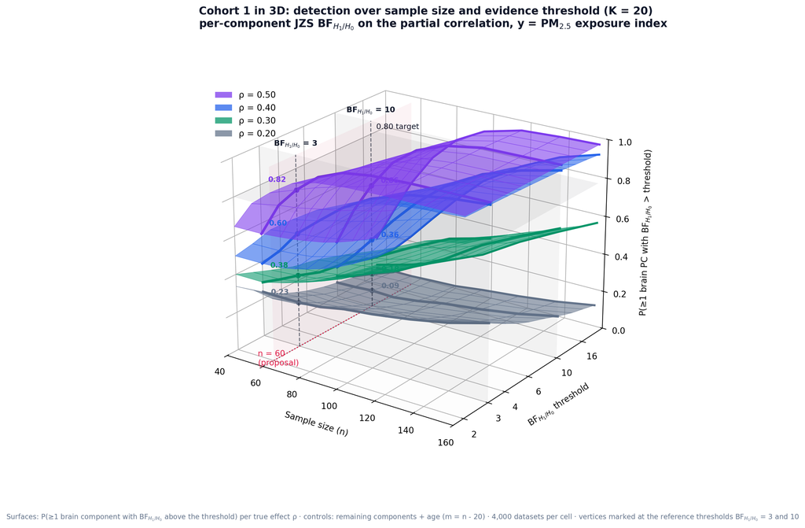

Cohort 1 in 3D: probability that at least one brain component clears the per-component $\mathrm{BF}_{H_1/H_0}$ threshold, over sample size and threshold, one surface per true effect $\rho$ ($K=20$). The vertical posts mark $n=60$ at the reference thresholds $\mathrm{BF}_{H_1/H_0}=3$ and $10$.

## 3.4 Cohort 2: MCI vs. HC with the exposure in the model

Cohort 2 (Bayesian Lasso on $20$ brain components + PM$_{2.5}$ exposure + age; success = $\ge1$ brain component with $95\%$ CrI excluding 0; no exposure group effect, $d_h=0$). “n.a.” = not attainable with $n\le80$ per group.

| MCI–HC separation (1 component) | $d=0.50$ | $d=0.65$ | $d=0.80$ | $d=1.00$ |
| --- | --- | --- | --- | --- |
| Required $n$ per group | n.a. | 70 | **42** | **26** |
| $P(\ge1)$ at $30$/group | 0.350 | 0.468 | 0.632 | **0.875** |

Family-wise false detection under the global null: $0.168$ at $30$/group, $0.185$ at $40$/group; false significance of the PM$_{2.5}$ exposure coefficient when it has no group effect: $\approx0.01$.

Under the pipeline criterion, $30$ per group reaches $0.632$ at $d=0.8$ and $0.875$ at $d=1.0$; securing the $0.80$ target at $d=0.8$ requires $42$ per group ($26$ per group suffice at $d=1.0$, while $d=0.65$ requires $70$). Regarding the PM$_{2.5}$ exposure itself: its inclusion in the model costs essentially nothing (its false-significance rate is $\approx1\%$), but a small MCI–HC exposure difference ($d_h=0.3$, about $1$ $\mu$g/m$^{3}$ between groups) is rarely detected at these sample sizes ($P\le0.20$ up to $80$ per group; Figure 6B), so exposure group effects in Cohort 2 should be framed as exploratory rather than confirmatory.

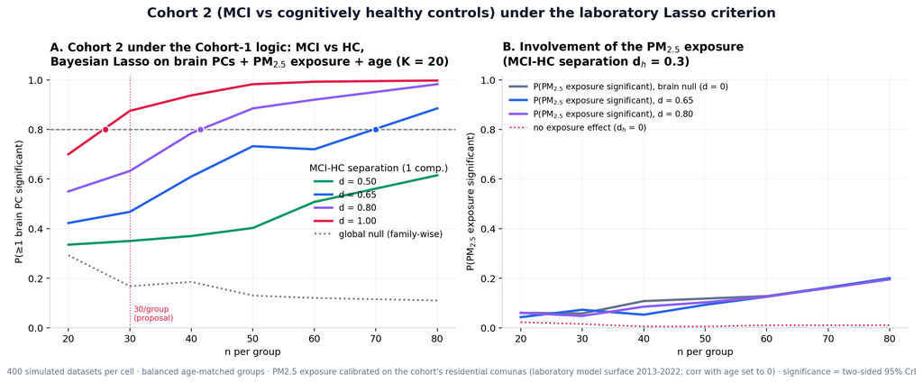

Cohort 2 under the laboratory Lasso criterion with the PM$_{2.5}$ exposure in the model. (A) Probability that at least one brain component separates MCI from HC. (B) Probability that the exposure coefficient is significant when the true MCI–HC exposure separation is $d_h=0.3$.

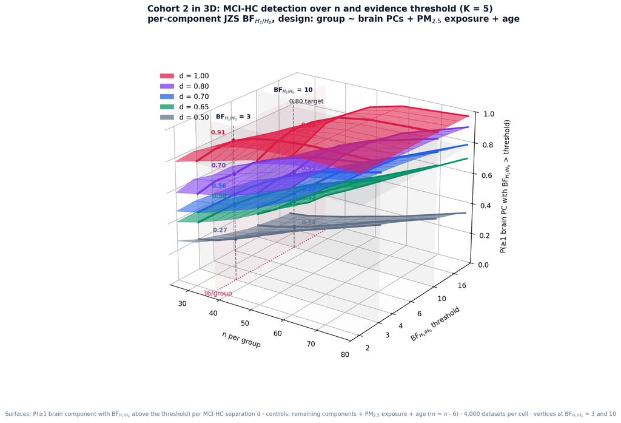

Cohort 2 in 3D: probability that at least one brain component clears the per-component $\mathrm{BF}_{H_1/H_0}$ threshold, over $n$ per group and the threshold, one surface per MCI–HC separation $d$ ($K=5$, exposure in the model). Vertical posts mark $36$ per group at $\mathrm{BF}_{H_1/H_0}=3$ and $10$.

# 4 Conclusion

Two practical advantages of the exposure arm follow. First, the exposure index costs nothing per participant: it is reconstructed from the residential comuna, and $600$ of the $601$ current records already carry an assigned exposure across $52$ comunas, so the binding constraint is imaging, not exposure assessment. A nested design that adds structural MRI to approximately $142$ georeferenced participants would power the moderate single-component scenario, while the full multimodal protocol is retained in a $60$ to $72$ participant core. Second, recruitment can actively widen the exposure contrast: oversampling residents of low-exposure comunas (Las Condes, Lo Barnechea, San José de Maipo) and of comunas outside the metropolitan region would raise the exposure SD above $3.2$ $\mu$g/m$^{3}$ and make every tabulated scenario easier to reach.

# 5 Reproducibility

All computations use fixed seeds. The engine is `bfda_lasso_multivariante.py` with the flag `--predictor pm25` (plus `--extra`, `--beta-posterior`, `--cohorte2` for the corresponding sections); outputs land in `results/pm25/`. Calibration inputs: `data/calibracion_pm25.csv` (participant-level residential exposure, built from the model’s daily surface `pm25_comunal_diario.csv`, aggregated 2013–2022 in `pm25_modelo_media_comunal_2013_2022.csv`, and the recruitment database) and `data/calibracion_dkt_eigenvalues.csv`.

## References

Donkelaar, Aaron van, Melanie S. Hammer, Liam Bindle, et al. 2021. “Monthly Global Estimates of Fine Particulate Matter and Their Uncertainty.” *Environmental Science & Technology* 55 (22): 15287–300.